### Predicting Movie’s Popularity with Bayesian Model

#### December 29, 2016

## Setup

### Load packages

```r
library(ggplot2)
library(dplyr)
library(statsr)
library(tidyr)
library(BAS)
```

### Load data

```r
load("movies.Rdata")
dim(movies)
```

```
## [1] 651  32
```

## Part 1: Data

Curtesy of Rotten Tomatoes and IMDb, our dataset contains a random sample of 651 movies, each comes with 32 selected pieces of informaiton, that were produced and released between 1970 and 2014 in the United States. In addition to ratings/scores from both audience and film critics, the dataset contains standard information regarding each movie such as genre, running time, MPAA rating, production studio, Oscar nominations, and etc.

With this dataset and for the purpose of this project it is only possible to do an observational study and no causal analysis is done. Overall, it is assumed that the individual movie observations are independent of each other. The study can generalize to movies produced and released between 1970 and 2014.

## Part 2: Research question

As the newly hired data scientist at Paramount Pictures, I’m tasked to find out if certain attributies and/or film critic’s rating/score could predict the pouplarity of a movie. In our case, the closest available proxy for movie popularity is the audience rating/score.

The research question in this study is:

> Is there a significant relationship between audience score, movie features and critics rating?

For this study we want to determine how does the type of movie, runtime, awards obtained (actors, director and picture) and critics score relates to the popularity of a movie. Answering this question con provide some insights to determine what characteristics are more influential to establish the popularity of a movie.

## Part 3: Exploratory data analysis

### Data Preparation

In addition to the original variables in the raw data set, the following variables were further processed/manipulated for our analysis.

```
1. feature_film with two levels yes and no
2. drama with two levels yes and no
3. mpaa_rating_R with two levels yes and no
4. oscar_season and
5. summer_season, each with two levels yes and no
```

```r
movies <- mutate(movies,feature_film=as.factor(ifelse(title_type=='Feature Film','yes','no')))
movies <- mutate(movies,drama=as.factor(ifelse(genre=='Drama', 'yes', 'no')))
movies <- mutate(movies,mpaa_rating_R=as.factor(ifelse(mpaa_rating=='R', 'yes', 'no')))
movies <- mutate(movies,oscar_season=as.factor(ifelse(thtr_rel_month %in% c(10:12), 'yes', 'no')))
movies <- mutate(movies,summer_season=as.factor(ifelse(thtr_rel_month %in% c(5:8), 'yes', 'no')))
```

### Data Visualization

The following charts show a breakdown of various movie characteristics.

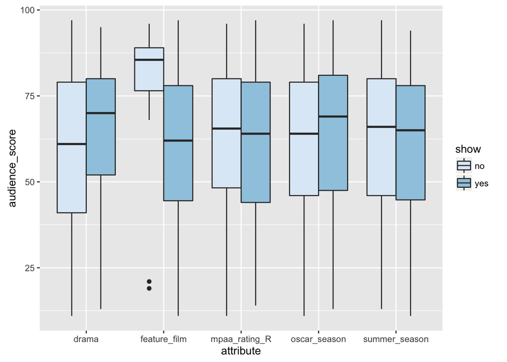

```r
new <- movies %>% gather('attribute','show',feature_film:summer_season)

ggplot(data=new,aes(x=attribute, y= audience_score,fill=show))+geom_boxplot()+ scale_fill_brewer()
```

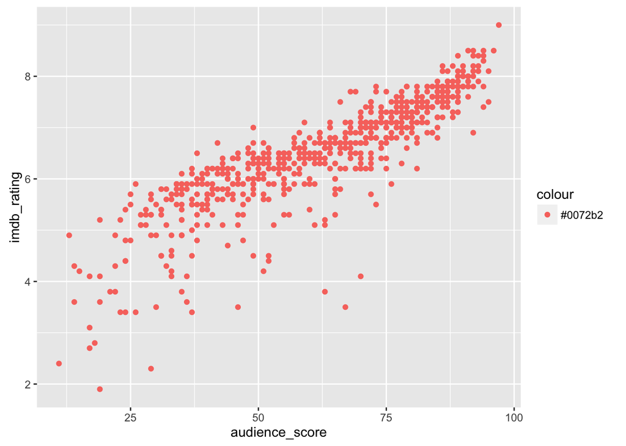

```r
ggplot(data=movies, aes(x=audience_score, y=imdb_rating))+geom_point(aes(col="#0072b2"))
```

We can see that title_type, genre and imdb_rtingare significant to audience score so they will surely be inlcuded in our predictive model.

## Part 4: Modeling

Here, I will try to predict the popularity of a movie by using a linear regression model and bayesian model aveaging. As follows, a bayesian linear regression model has been created by incoprating all the available predictors.

```r
bay_model <- bas.lm(data=na.omit(movies), audience_score ~ feature_film + drama + runtime + mpaa_rating_R + thtr_rel_year + oscar_season + summer_season + imdb_rating + imdb_num_votes + critics_score + best_pic_nom + best_pic_win + best_actor_win + best_actress_win + best_dir_win + top200_box, prior = 'BIC', modelprior = uniform())

bay_model
```

```
##
## Call:
## bas.lm(formula = audience_score ~ feature_film + drama + runtime +     mpaa_rating_R + thtr_rel_year + oscar_season + summer_season +     imdb_rating + imdb_num_votes + critics_score + best_pic_nom +     best_pic_win + best_actor_win + best_actress_win + best_dir_win +     top200_box, data = na.o…
##
##
##  Marginal Posterior Inclusion Probabilities:
##           Intercept      feature_filmyes             dramayes
##             1.00000              0.05876              0.04509
##             runtime     mpaa_rating_Ryes        thtr_rel_year
##             0.51400              0.16498              0.08089
##     oscar_seasonyes     summer_seasonyes          imdb_rating
##             0.06526              0.07935              1.00000
##      imdb_num_votes        critics_score      best_pic_nomyes
##             0.06242              0.92016              0.13201
##     best_pic_winyes    best_actor_winyes  best_actress_winyes
##             0.04077              0.11565              0.14770
##     best_dir_winyes        top200_boxyes
##             0.06701              0.04876
```

We can see that imdb_rating, critics score and runtime all have high posterior probability.

```r
summary(bay_model)
```

```
##      Intercept feature_filmyes dramayes runtime mpaa_rating_Ryes
## [1,]         1               0        0       1                0
## [2,]         1               0        0       0                0
## [3,]         1               0        0       0                0
## [4,]         1               0        0       1                1
## [5,]         1               0        0       1                0
##      thtr_rel_year oscar_seasonyes summer_seasonyes imdb_rating
## [1,]             0               0                0           1
## [2,]             0               0                0           1
## [3,]             0               0                0           1
## [4,]             0               0                0           1
## [5,]             0               0                0           1
##      imdb_num_votes critics_score best_pic_nomyes best_pic_winyes
## [1,]              0             1               0               0
## [2,]              0             1               0               0
## [3,]              0             1               0               0
## [4,]              0             1               0               0
## [5,]              0             1               1               0
##      best_actor_winyes best_actress_winyes best_dir_winyes top200_boxyes
## [1,]                 0                   0               0             0
## [2,]                 0                   0               0             0
## [3,]                 0                   1               0             0
## [4,]                 0                   0               0             0
## [5,]                 0                   0               0             0
##             BF PostProbs     R2 dim   logmarg
## [1,] 1.0000000    0.1558 0.7483   4 -3434.752
## [2,] 0.8715404    0.1358 0.7455   3 -3434.889
## [3,] 0.2048238    0.0319 0.7470   4 -3436.338
## [4,] 0.2039916    0.0318 0.7496   5 -3436.342
## [5,] 0.1851908    0.0289 0.7495   5 -3436.438
```

We see that the best model includes intercept, imdb_rating, critics_score and runtime, and we need to visualize the results.

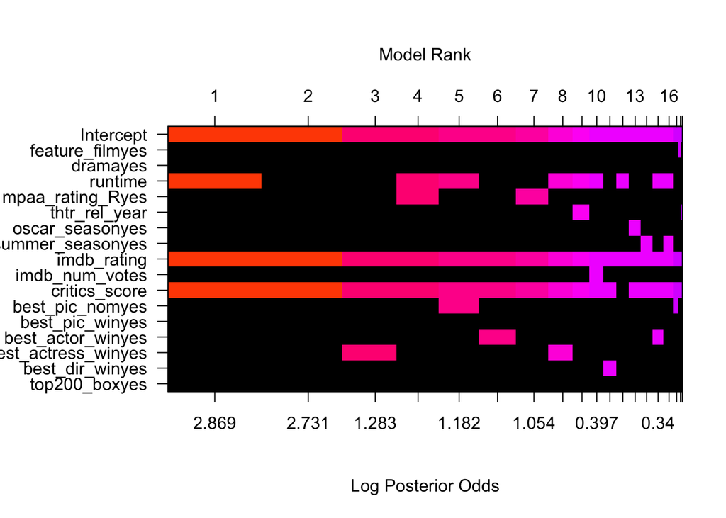

```r
image(bay_model, rotate = F)
```

As we can see that the runtime, imdb_rating, critics_score are inlcuded in the at least over half of the model. I will apply these 3 variables to build the final model.

```r
final_model <- bas.lm(data=na.omit(movies),audience_score ~ imdb_rating+critics_score+runtime,
                      modelprior = uniform(),
                      prior="ZS-null",
                      method = "MCMC")
final_model
```

```
##
## Call:
## bas.lm(formula = audience_score ~ imdb_rating + critics_score +     runtime, data = na.omit(movies), prior = "ZS-null", modelprior = uniform(),     method = "MCMC")
##
##
##  Marginal Posterior Inclusion Probabilities:
##     Intercept    imdb_rating  critics_score        runtime
##        1.0000         1.0000         0.9186         0.5053
```

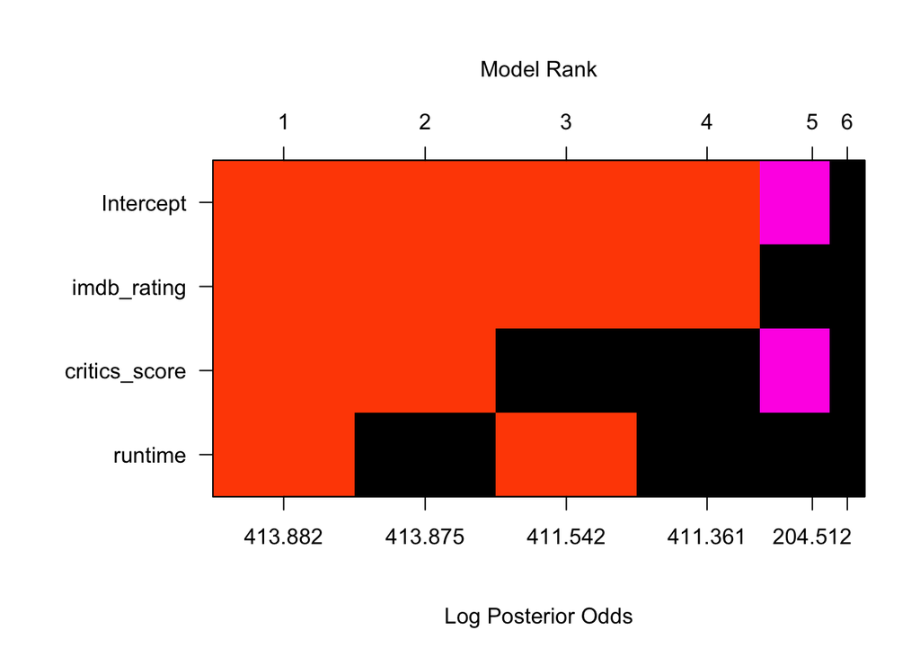

```r
image(final_model,rotate = F)
```

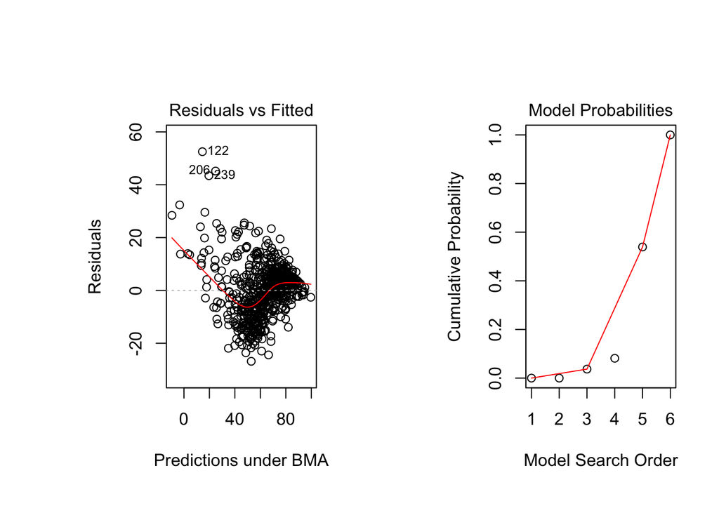

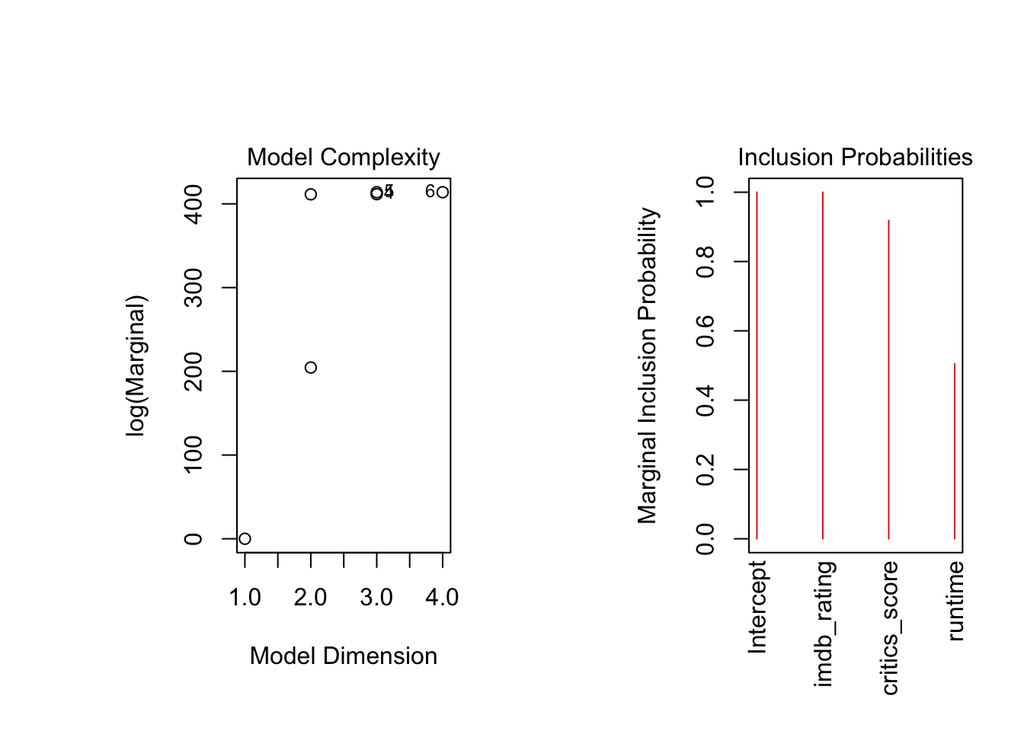

```r
par(mfrow=c(1,2))
plot(final_model)
```

```r
coef.final <- coef(final_model)
coef.final
```

```
##
##  Marginal Posterior Summaries of Coefficients:
##                post mean  post SD   post p(B != 0)
## Intercept      62.21002    0.40911   1.00000
## imdb_rating    14.87901    0.74261   1.00000
## critics_score   0.07021    0.02992   0.91855
## runtime        -0.02936    0.03312   0.50533
```

## Part 5: Prediction

The movie I’ve chosen for testing our predictive model is ‘Deadpool’. The information about this movie is obtained from IMDb and Rotton Tomatoes.

```
1. audience_score = 90
2. runtime = 108
3. imdb_rating = 8.1
4. critic_score = 84
```

```r
Deadpool <- data.frame(audience_score = 0, runtime=108,imdb_rating = 8.1,critics_score=84)
predict_score <- predict(final_model,Deadpool,estimator = "BMA")$fit
predict_score
```

```
##          [,1]
## [1,] 88.05304
```

The true audience score for the movie is 90 while our predicted score is 88. Not too shabby!

## Part 6: Conclusion

In this analysis, our linear regression model using bayesian model averaging proves to have good capability for predicting movie popularity based on certain movie characteristics. Further analysis should be conudtced to address some unanswered issues, such as effect from big movie franchises (i.e Harry Potter)